# Wrangle SPINS gradients with GSR

## fitting models

Models

- model includes DX, sex, age, scanner, fd?
- what about between task -
  - do paired ttest?

So the current df is here: /projects/loliver/SPINS_PLS_Conn/data/processed/spins_behav_ea_conn_04-29-2021.csv 6:27 However, I also excluded ZHP_0110 and ZHP_0172 as they did not complete the soc cog tasks 6:27 So that df includes 356, but my current N is 354

The following participants were missing task-rest cleaned files: sub-CMP0180 sub-CMP0182 sub-CMP0191 sub-CMP0196 sub-CMP0198 sub-CMP0207 sub-CMP0213 sub-ZHH0034

The following participants were missing task-emp background files: sub-CMH0025 sub-CMH0044 sub-CMH0095 sub-CMH0138 sub-MRC0075 sub-MRP0077 sub-MRP0147 sub-MRP0149 sub-MRP0151 sub-MRP0161 sub-ZHH0038 sub-ZHP0061 sub-ZHP0086

```r
overall_grand_mean_grads <- spins_grads %>%
  mutate(Network = factor(Network, levels = networks$NETWORK)) %>%
  filter(Subject %in% lol_spins_behav$subject) %>%
  group_by(Task, ROI, Network, GSR) %>%
  summarise_at(vars(grad1:grad3), mean)

#grand_mean_grads
```

```r
## a very convoluted way to pull networks of interest
networks_of_interest <- overall_grand_mean_grads %>%
  group_by(Network) %>%
  summarise_at(vars(grad1:grad3), mean) %>%
  pivot_longer(starts_with("grad"),
               names_to = "grad_name",
               values_to = "grad_value") %>%
  filter(abs(grad_value) > 0.2) %>%
  distinct(Network) %>%
  pull(Network) %>% as.character()
```

```r
grand_mean_grads <- spins_grads %>%
  mutate(Network = factor(Network, levels = networks$NETWORK)) %>%
  filter(Subject %in% lol_spins_behav$subject) %>%
  group_by(Site, Task, ROI, Network, GSR) %>%
  summarise_at(vars(grad1:grad3), mean)

#grand_mean_grads
```

```r
glasser_atlas <-
  ggsegGlasser::glasser %>% as.tibble() %>% select(hemi, region, side, label)
```

```
## merging atlas and data by 'label'
```

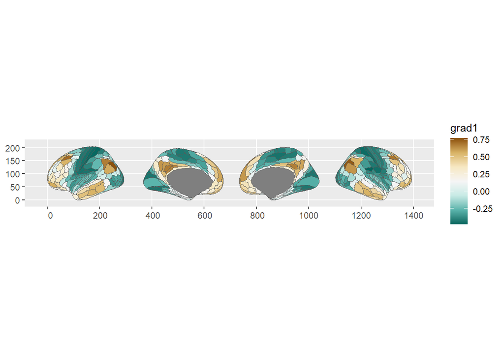

```r
overall_grads_for_plot <- overall_grand_mean_grads %>%
  mutate(roi = str_remove(ROI, "_ROI"),
         label = case_when(str_starts(ROI, "L") ~ str_c("lh_", roi),
                           str_starts(ROI, "R_") ~ str_c("rh_", roi))) %>%

  filter(Task == "RS", GSR == "GSR") %>%
  select(starts_with("grad"), label)
overall_grads_for_plot %>%
  filter(Network != "Subcortical") %>%
  filter(ROI != "L_10pp_ROI") %>%
  as.data.frame() %>%
  ggplot() +
  geom_brain(mapping = aes(fill = grad1),
        atlas = glasser) +
  scale_fill_distiller(type = "div")
```

```
## merging atlas and data by 'label'
```

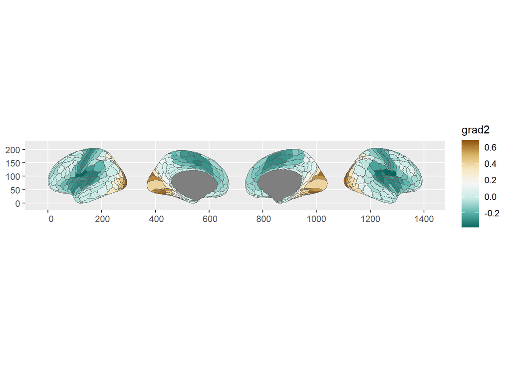

```r
overall_grads_for_plot %>%
  filter(Network != "Subcortical") %>%
  filter(ROI != "L_10pp_ROI") %>%
  as.data.frame() %>%
  ggplot() +
  geom_brain(mapping = aes(fill = grad2),
        atlas = glasser) +
  scale_fill_distiller(type = "div")
```

```
## merging atlas and data by 'label'
```

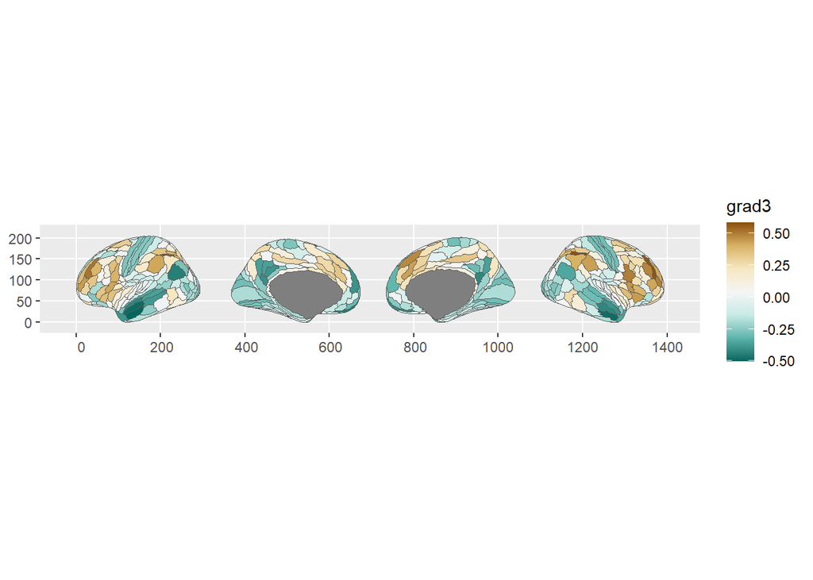

```r
overall_grads_for_plot %>%
  filter(Network != "Subcortical") %>%
  filter(ROI != "L_10pp_ROI") %>%
  as.data.frame() %>%
  ggplot() +
  geom_brain(mapping = aes(fill = grad3),
        atlas = glasser) +
  scale_fill_distiller(type = "div")
```

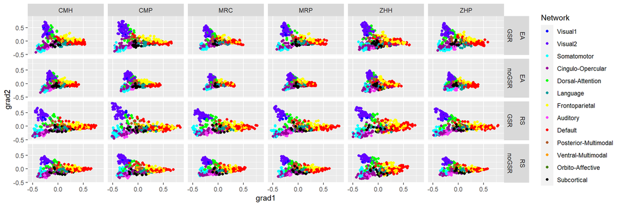

```r
grand_mean_grads %>%
  ggplot(aes(x = grad1, y = grad2, colour = Network)) +
  geom_point() +
  scale_color_manual(values = networks$hex) +
  facet_grid(Task*GSR ~ Site)
```

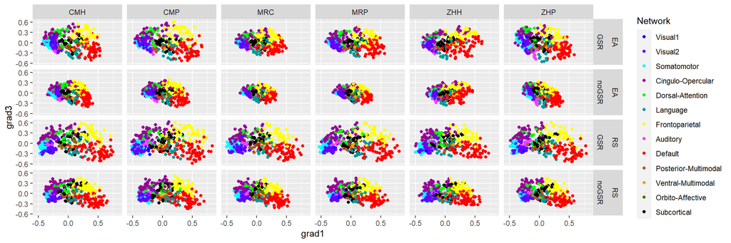

```r
grand_mean_grads %>%
  ggplot(aes(x = grad1, y = grad3, colour = Network)) +
  geom_point() +
  scale_color_manual(values = networks$hex) +
  facet_grid(Task*GSR ~ Site)
```

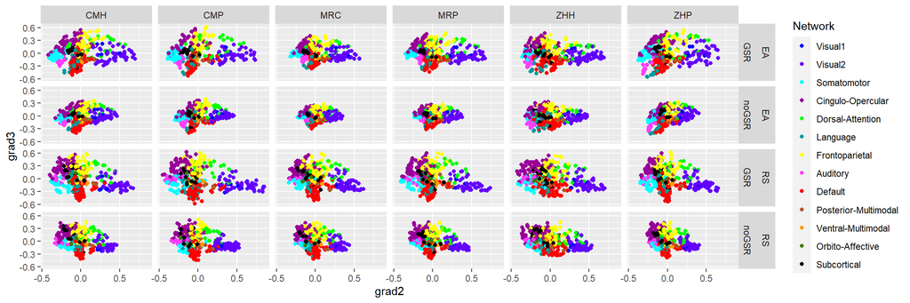

```r
grand_mean_grads %>%
  ggplot(aes(x = grad2, y = grad3, colour = Network)) +
  geom_point() +
  scale_color_manual(values = networks$hex) +
  facet_grid(Task*GSR ~ Site)
```

From age paper: Each axis of this 3D space was defined by the values along the first three gradients. Within network dispersion was quantified as sum squared Euclidean distance of network nodes to the network centroid at individual level. Between network dispersion was calculated as the Euclidean distance between network centroids.

They also did linear models on nodal values from the first three gradients

## calculating centroid and within network dispersion

```r
## calculate the network centers
subject_level_centers <- spins_grads %>%
  filter(Subject %in% lol_spins_behav$subject) %>%
  group_by(Site, Task, Network, Subject, GSR) %>%
  summarise_at(c("grad1", "grad2", "grad3"), mean)

subject_within_dispersion <- subject_level_centers %>%

  ## combine with orig spins grads
  inner_join(spins_grads, by = c("Site", "Task", "Network", "Subject", "GSR"), suffix = c("_center", "")) %>%

  ## calculate squared euclidian distance from the network centroid
  ungroup() %>%
  mutate(roi_distance_sq = (grad1_center - grad1)**2 + (grad2_center - grad2)**2 + (grad3_center - grad3)**2) %>%

  ## dispersion as the sum of the squared distances within network and participant
  group_by(Site, Task, GSR, Network, Subject) %>%
  summarise(within_dispersion = sum(roi_distance_sq))
```

## calculating between network dispersion

Between network dispersion was calculated as the Euclidean distance between network centroids.

```r
library(igraph)
## assumes that the network_centroids contains columns "Network", "grad1", "grad2", "grad3"
calc_between_distances <- function(network_centoids) {
  ## grab the unique network node names
  network_names <- unique(network_centoids$Network)

  ## create a graph dataframe of edges
  result <- make_full_graph(length(network_names), directed = FALSE) %>% as_data_frame()

  for (i in 1:nrow(result)) {
    to_name <- network_names[result$to[i]]
    from_name <- network_names[result$from[i]]

    result$to_name[i] <- to_name
    result$from_name[i] <- from_name

  res_df <- test_centroids %>%
    filter(Network == to_name | Network == from_name) %>%
    mutate_at(vars(c("grad1", "grad2", "grad3")), function(x) {(x - lag(x))**2}) %>%
    mutate(eucl_dist = sqrt(grad1 + grad2 + grad3))

  result$eucl_dist[i] <- res_df$eucl_dist[2]

  }

  return(result %>% select(to_name, from_name, eucl_dist))
}
```

```r
between_network <- subject_level_centers %>%
  ungroup() %>%
  group_by(Site, Task, Subject, GSR) %>%
  nest() %>%
  mutate(distances = map(data, calc_between_distances))
```

```r
between_network <- subject_level_centers %>%
  ungroup() %>%
  group_by(Site, Task, Subject, GSR) %>%
  nest() %>%
  slice(1)

between_network$data
```

[output not shown]

## testing for EMP vs REST differences

```r
library(broom)
subject_level_centers %>%
  filter(GSR=="GSR") %>%
  inner_join(lol_spins_behav, by = c("Subject" = "subject")) %>%
  mutate( fd_mean = if_else(Task=="EA", `fd_mean_task-emp`, `fd_mean_task-rest`)) %>%
  ungroup() %>%
  group_by(Network, GSR) %>%
  do(tidy(aov(grad1 ~ Task + fd_mean + scanner + Error(Subject), data = .))) %>%
  filter(term == "Task") %>%
  arrange(GSR) %>%
  knitr::kable()
```

| Network | GSR | stratum | term | df | sumsq | meansq | statistic | p.value |
| --- | --- | --- | --- | --- | --- | --- | --- | --- |
| Auditory | GSR | Within | Task | 1 | 2.1900044 | 2.1900044 | 176.950008 | 0.0000000 |
| Cingulo-Opercular | GSR | Within | Task | 1 | 0.4514620 | 0.4514620 | 97.158541 | 0.0000000 |
| Default | GSR | Within | Task | 1 | 2.2768143 | 2.2768143 | 346.303887 | 0.0000000 |
| Dorsal-Attention | GSR | Within | Task | 1 | 0.0566903 | 0.0566903 | 10.403232 | 0.0013779 |
| Frontoparietal | GSR | Within | Task | 1 | 1.7415183 | 1.7415183 | 279.869186 | 0.0000000 |
| Language | GSR | Within | Task | 1 | 0.1336693 | 0.1336693 | 13.019246 | 0.0003538 |
| Orbito-Affective | GSR | Within | Task | 1 | 0.2818028 | 0.2818028 | 26.234163 | 0.0000005 |
| Posterior-Multimodal | GSR | Within | Task | 1 | 0.3708879 | 0.3708879 | 29.857603 | 0.0000001 |
| Somatomotor | GSR | Within | Task | 1 | 1.9922087 | 1.9922087 | 230.084048 | 0.0000000 |
| Subcortical | GSR | Within | Task | 1 | 0.0452532 | 0.0452532 | 7.642142 | 0.0060074 |
| Ventral-Multimodal | GSR | Within | Task | 1 | 0.2313998 | 0.2313998 | 11.540165 | 0.0007604 |
| Visual1 | GSR | Within | Task | 1 | 0.0333014 | 0.0333014 | 1.575445 | 0.2102650 |
| Visual2 | GSR | Within | Task | 1 | 1.5446533 | 1.5446533 | 203.348354 | 0.0000000 |

## fit case-control and age differences in gradient dispersion

```r
results_subject_within_dispersion <- subject_within_dispersion %>%
  filter(GSR=="GSR", Task=="RS") %>%
  inner_join(lol_spins_behav, by = c("Subject" = "subject")) %>%
  mutate( fd_mean = if_else(Task=="EA", `fd_mean_task-emp`, `fd_mean_task-rest`)) %>%
  group_by(Network, Task, GSR) %>%
  do(tidy(lm(within_dispersion ~ diagnostic_group + demo_age_study_entry + demo_sex + fd_mean + scanner, data = .))) %>%
  ungroup() %>%
  group_by(term) %>%
  mutate(p_FDR = p.adjust(p.value, method = "fdr"))

results_subject_within_dispersion %>%
  filter(term %in% c("diagnostic_groupcontrol",
                     "demo_age_study_entry")) %>%
  arrange(GSR) %>%
  filter(Network %in% networks_of_interest) %>%
  knitr::kable()
```

| Network | Task | GSR | term | estimate | std.error | statistic | p.value | p_FDR |
| --- | --- | --- | --- | --- | --- | --- | --- | --- |
| Auditory | RS | GSR | diagnostic_groupcontrol | 0.1000531 | 0.0682278 | 1.4664560 | 0.1434538 | 0.3246192 |
| Auditory | RS | GSR | demo_age_study_entry | 0.0004922 | 0.0037147 | 0.1324884 | 0.8946768 | 0.8946768 |
| Default | RS | GSR | diagnostic_groupcontrol | 0.4600265 | 0.4814294 | 0.9555431 | 0.3399860 | 0.4128944 |
| Default | RS | GSR | demo_age_study_entry | -0.0123312 | 0.0262114 | -0.4704528 | 0.6383350 | 0.8946768 |
| Frontoparietal | RS | GSR | diagnostic_groupcontrol | -0.7292055 | 0.3033469 | -2.4038670 | 0.0167605 | 0.0726289 |
| Frontoparietal | RS | GSR | demo_age_study_entry | -0.0220816 | 0.0165157 | -1.3370012 | 0.1821214 | 0.6313438 |
| Somatomotor | RS | GSR | diagnostic_groupcontrol | 0.4283707 | 0.2191968 | 1.9542748 | 0.0514930 | 0.1673522 |
| Somatomotor | RS | GSR | demo_age_study_entry | 0.0016496 | 0.0119342 | 0.1382243 | 0.8901455 | 0.8946768 |
| Visual1 | RS | GSR | diagnostic_groupcontrol | -0.0745648 | 0.0548345 | -1.3598146 | 0.1747950 | 0.3246192 |
| Visual1 | RS | GSR | demo_age_study_entry | -0.0005490 | 0.0029855 | -0.1839043 | 0.8541988 | 0.8946768 |
| Visual2 | RS | GSR | diagnostic_groupcontrol | 0.2540964 | 0.3761654 | 0.6754910 | 0.4998257 | 0.5414779 |
| Visual2 | RS | GSR | demo_age_study_entry | 0.0081778 | 0.0204803 | 0.3992983 | 0.6899256 | 0.8946768 |

```r
results_subject_within_dispersion %>%
  filter(term == "demo_age_study_entry") %>%
  knitr::kable()
```

| Network | Task | GSR | term | estimate | std.error | statistic | p.value | p_FDR |
| --- | --- | --- | --- | --- | --- | --- | --- | --- |
| Auditory | RS | GSR | demo_age_study_entry | 0.0004922 | 0.0037147 | 0.1324884 | 0.8946768 | 0.8946768 |
| Cingulo-Opercular | RS | GSR | demo_age_study_entry | -0.0149808 | 0.0178713 | -0.8382650 | 0.4024743 | 0.8946768 |
| Default | RS | GSR | demo_age_study_entry | -0.0123312 | 0.0262114 | -0.4704528 | 0.6383350 | 0.8946768 |
| Dorsal-Attention | RS | GSR | demo_age_study_entry | 0.0120744 | 0.0092833 | 1.3006638 | 0.1942596 | 0.6313438 |
| Frontoparietal | RS | GSR | demo_age_study_entry | -0.0220816 | 0.0165157 | -1.3370012 | 0.1821214 | 0.6313438 |
| Language | RS | GSR | demo_age_study_entry | -0.0051600 | 0.0092896 | -0.5554598 | 0.5789476 | 0.8946768 |
| Orbito-Affective | RS | GSR | demo_age_study_entry | 0.0029310 | 0.0019056 | 1.5380607 | 0.1249694 | 0.6313438 |
| Posterior-Multimodal | RS | GSR | demo_age_study_entry | 0.0014014 | 0.0036340 | 0.3856412 | 0.7000050 | 0.8946768 |
| Somatomotor | RS | GSR | demo_age_study_entry | 0.0016496 | 0.0119342 | 0.1382243 | 0.8901455 | 0.8946768 |
| Subcortical | RS | GSR | demo_age_study_entry | -0.0151717 | 0.0105011 | -1.4447802 | 0.1494460 | 0.6313438 |
| Ventral-Multimodal | RS | GSR | demo_age_study_entry | 0.0006235 | 0.0012802 | 0.4870466 | 0.6265410 | 0.8946768 |
| Visual1 | RS | GSR | demo_age_study_entry | -0.0005490 | 0.0029855 | -0.1839043 | 0.8541988 | 0.8946768 |
| Visual2 | RS | GSR | demo_age_study_entry | 0.0081778 | 0.0204803 | 0.3992983 | 0.6899256 | 0.8946768 |